# Homework #1

See all that stuff above. You should change `theme` and `highligh-style` to fit your own style. You can find them here: https://quarto.org/docs/output-formats/html-themes.html

Seriously, you should start finding your own style, so definitely change them!

## Data

You’ll be working with the following data files:

- `artist_genre.txt`
- `artist_name.csv`
- `artist_net_worth.csv`
- `artist_number_one_hits.csv`
- `artist_studio_albums.csv`
- `artist_top_hits.csv`

The only file that you are going to need to be careful about is the `artist_genre` file – be sure to look at the extension, refer to the notes on I/O, and read the help file!

## Goals

Read the files in and then accomplish the following goals:

```r
#since.txt we use read.table, rest.csv

artist_genre <- read.table("C:/Users/azizm/Documents/Uni/Data_Wrangling/artist_genre.txt", header=T)
artist_BY <- read.csv("C:/Users/azizm//Documents/Uni/Data_Wrangling/artist_name.csv")
artist_nw <- read.csv("C:/Users/azizm/Documents/Uni/Data_Wrangling/artist_net_worth.csv")
artist_ones <- read.csv("C:/Users/azizm/Documents/Uni/Data_Wrangling/artist_number_one_hits.csv")
artist_albums <- read.csv("C:/Users/azizm/Documents/Uni/Data_Wrangling/artist_studio_albums.csv")
artist_top <- read.csv("C:/Users/azizm/Documents/Uni/Data_Wrangling/artist_top_hits.csv")
```

### Pre-join Goals

- Use the aggregate function to ensure that each file only contains unique rows.
- If duplicates exist, handle them. You can either de-duplicate them (the `duplicate` function is helpful here) or `aggregate` them to single rows. The choice is yours and yours alone, but be sure to justify your decision.

```r
#using the aggregate and unique functions together, we can guarantee that the rows are unique.
#we do not need to use duplicate necessarily since each artist has a unique row and not multiple entries with different top hits or genres. (With duplicate no need to use unique function but I understand aggregate function more :) )

clean_genre <- aggregate(genre~Artist, artist_genre, FUN = unique)
clean_albums <- aggregate(studio_albums~Artist, artist_albums, FUN = unique)
clean_BY <- aggregate(Birth_Year~Artist, artist_BY, FUN = unique)
clean_nw <- aggregate(net_worth_millions~Artist, artist_nw, FUN = unique)
clean_ones <- aggregate(number_one_hits~artist, artist_ones, FUN = unique)
clean_top <- aggregate(cbind(Top_Hit,Year)~Artist, artist_top, FUN = unique)

#so all of the artist columns are titled the same

colnames(clean_ones)[1] <- "Artist"

#check data types of all columns using str
#remove dollar signs from all row values in clean_nw, then make sure all values are treated as integers
#(same data type as all the other values incase we need to merge or use data from other tables)

clean_nw$net_worth_millions <-gsub("\\$","",clean_nw$net_worth_millions)

clean_nw$net_worth_millions <- as.integer(clean_nw$net_worth_millions)
```

- Which 5 artists have the greatest net worth?

```r
#make a new df ordered in descending order of net worth values
#then look into first 15 observations

highest_nw <- clean_nw[order(clean_nw$net_worth_millions,decreasing=TRUE),]

head(highest_nw,n=5)
```

```
               Artist net_worth_millions
25              Jay-Z               1500
54        The Beatles               1500
1                ABBA                900
58 The Rolling Stones                900
38            Madonna                850
```

```r
#artists can make a lot of money (no matter the genre), like 100s of millions or even billions of dollars
```

- Which 15 artists have the most number 1 hits?

```r
#make a new df ordered in descending order of number 1 hits
#then look into first 15 observations

most_ones <- clean_ones[order(clean_ones$number_one_hits,decreasing=TRUE),]

head(most_ones,n=15)
```

```
               Artist number_one_hits
54        The Beatles              20
39       Mariah Carey              19
19      Elvis Presley              18
47            Rihanna              14
41    Michael Jackson              13
38            Madonna              12
61    Whitney Houston              11
51      Stevie Wonder              10
32         Katy Perry               9
15              Drake               8
58 The Rolling Stones               8
12         Bruno Mars               7
52       Taylor Swift               7
16         Ed Sheeran               6
18         Elton John               6
```

```r
#being at the the top helps with net worth but there are other ways to make money for artists (Jay Z is not on this list but still
#has the highest net worth)
```

- Which 10 artists have the fewest studio albums?

```r
#make a new df ordered in ascending order of number of studio albums,
#then look into first 10 observations

least_albums <- clean_albums[order(clean_albums$studio_albums),]
head(least_albums,n=10)
```

```
                 Artist studio_albums
8         Billie Eilish             1
37                Lorde             2
56 The Notorious B.I.G.             2
2                 Adele             3
12           Bruno Mars             3
26         Jimi Hendrix             3
42              Nirvana             3
48            Sam Smith             3
24      Imagine Dragons             4
31    Justin Timberlake             4
```

```r
#Bruno Mars didn't need many albums to make number 1 hits
```

After you have those done, you can join your data frames together.

```r
#use merge function to merge columns from all th clean data using Artist as common column

artist_comb <- merge(clean_BY, clean_genre, 'Artist')
artist_comb <- merge(artist_comb, clean_top, 'Artist')
artist_comb <- merge(artist_comb, clean_ones, 'Artist')
artist_comb <- merge(artist_comb, clean_albums, 'Artist')
artist_comb <- merge(artist_comb, clean_nw, 'Artist')

#for aesthetic purposes and (for when the plot labels are needed) change lower case column names to capital

colnames(artist_comb)[c(3, 6, 7, 8)] <- c("Genre", "Number_One_Hits", "Studio_Albums" , "Net_Worth_Millions")

#another way (capitalize all titles)
# library(magrittr)
# colnames(artist_comb) <- gsub("_", " ", colnames(artist_comb)) %>%
#   stringr::str_to_title(.) %>%
#   gsub(" ", "_", .)
```

### Post-join Goals

- Create variables to capture the following ideas:
  - How long has the artist been around? You can just use their birth year.

```r
#using str in console we can see birth year is stored as integer
#so we need to convert the current date to an integer
#to be able to find the difference
#use print the see the outcome

current_date <- as.integer(format(Sys.Date(), '%Y'))

artist_comb$Been_Around <- current_date - artist_comb$Birth_Year

print(artist_comb[,c('Artist', 'Been_Around')])
```

```
                 Artist Been_Around
1                  ABBA          79
2                 Adele          36
3             Aerosmith          76
4           Alicia Keys          43
5       Aretha Franklin          82
6         Ariana Grande          31
7               Beyoncé          43
8         Billie Eilish          23
9             Bob Dylan          83
10           Bob Marley          79
11             Bon Jovi          62
12           Bruno Mars          39
13             Coldplay          47
14          David Bowie          77
```

[output cut: 47 more lines]

```r
#There are a wide range of artists from different eras in this dataset with
#the least being around for 23 years and the most being around for 109 years
```

```
+ Something to capture each artist's net worth per studio album.
```

```r
#both are integers so we can instantly define a new column where we divide the nw by albums
#use print the see the outcome

artist_comb$Net_Worth_Millions_per_Album <- artist_comb$Net_Worth_Millions / artist_comb$Studio_Albums

print(artist_comb[,c('Artist', 'Net_Worth_Millions_per_Album')])
```

```
                 Artist Net_Worth_Millions_per_Album
1                  ABBA                  112.5000000
2                 Adele                   63.3333333
3             Aerosmith                   17.3333333
4           Alicia Keys                   21.4285714
5       Aretha Franklin                    1.9047619
6         Ariana Grande                   25.0000000
7               Beyoncé                   62.8571429
8         Billie Eilish                   25.0000000
9             Bob Dylan                   10.2564103
10           Bob Marley                   10.0000000
11             Bon Jovi                   27.3333333
12           Bruno Mars                   58.3333333
13             Coldplay                   35.0000000
14          David Bowie                    8.5185185
```

[output cut: 47 more lines]

```r
#there are only 3 people who have made more than 100 million dollars per album who also happen to be the people
#with the top 3 net worths
```

- Plot net worth per studio album, the “been around” variable, and genre. There should be points and colors here.

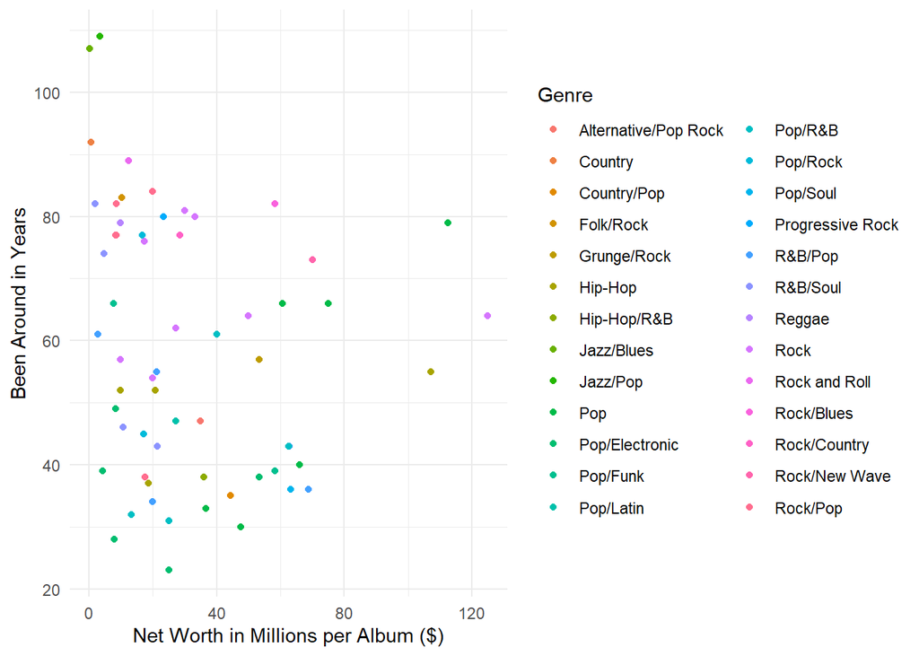

```r
#use ggplot to plot variables, since genre is a category it will use color while the rest use data points on graph

library(ggplot2)

ggplot(artist_comb, aes(Net_Worth_Millions_per_Album, Been_Around, color = Genre)) +
  geom_point() + theme_minimal() + labs(x ='Net Worth in Millions per Album ($)',
                                        y = 'Been Around in Years')
```

```r
#there are too many colors so it can be a bit confusing (not having labels for combinations can help)
#also, even though hard to identify, you can tell what genres have been around for a while (like Jazz/Blues and Jazz/Pop)
#and which ones are relatively new (like Pop/Electronic and Pop/Funk)
```